# Selective R Packages for Random Forests

Ruoqing Zhu

Last Updated: September 16, 2023

## R Packages for Random Forests

Here are some packages that will be used in this lecture.

- `randomForest` [[CRAN](https://cran.r-project.org/web/packages/randomForest/)] the vanilla random forest package
- `ranger` [[CRAN](https://cran.r-project.org/web/packages/ranger/)] a fast implementation of random forest
- `randomForestSRC` [[CRAN](https://cran.r-project.org/web/packages/randomForestSRC/)] added survival analysis capability and several additional features
- `grf` [[CRAN](https://cran.r-project.org/web/packages/grf/)] extended from the `ranger` package with additional statistical tools
- `RLT` Use new [[GitHub Ver. 4.2.5](https://github.com/teazrq/RLT)] a fast implementation and additional features. Old [[CRAN Ver. 3.2.6](https://cran.r-project.org/web/packages/RLT/)] will be updated later.

A more comprehensive list can be found [here](https://cran.r-project.org/web/views/MachineLearning.html).

## Install the `RLT` Package

### For Windows

In windows, `RLT` can be installed using `install_github`. The compilation of this package requires GCC. Hence, you may also need to install `Rtools` from [here](https://cran.r-project.org/bin/windows/Rtools/).

```r
  # you may need to install the devtools package first
  library(devtools)

  # install the RLT package from GitHub
  # Rtools is required in windows
  install_github("teazrq/RLT")
```

### For macOS

When installing RLT on macOS can be slightly trickier. It mainly consisting two steps:

- Step 1: Install compilers
  - Follow [this guild](https://mac.r-project.org/tools/) to install [GNU Fortran compiler, gfortran-12.2-universal.pkg](https://mac.r-project.org/tools/gfortran-12.2-universal.pkg)
  - If you do not already have Xcode (most systems come with Xcode installed already), you can use this line to install

    `sudo xcode-select --install`
- Step 2: Set `Markvars` to point to the compiler
  - Create the `Markvars` file using

    `makedir ~/.R`

    `touch ~/.R/Makevars`
  - Check your folder of `gfortran`. The compiler will be installed to `/opt/gfortran` folder as [default](https://github.com/R-macos/gcc-12-branch/releases)
  - Add these lines to point to the correct folder of the compiler. You may use `open -a TextEdit ~/.R/Makevars` to open a text editor and type in these lines.

    `FC = opt/gfortran/bin/gfortran`

    `F77 = /opt/gfortran/bin/gfortran`

    `FLIBS = -L/opt/gfortran/lib`

After completing these steps, you should be able to directly install the `RLT` package using `install_github("teazrq/RLT")` in RStudio the same way as windows machine. The compilation may require a few minutes.

### OpenMP in macOS

The previous steps would not activate OpenMP parallel computing, as explained [here](https://mac.r-project.org/openmp/). To enable OpenMP while compiling the `RLT` package, follow these steps:

- Step 1: download and install LLVM
  - For example, to install the 14.0.6 version (check the ones that compatible with your Xcode version), use

    `curl -O https://mac.r-project.org/openmp/openmp-14.0.6-darwin20-Release.tar.gz`

    `sudo tar fvxz openmp-14.0.6-darwin20-Release.tar.gz -C /`

    You should then see the following message

    `usr/local/lib/libomp.dylib`

    `usr/local/include/ompt.h`

    `usr/local/include/omp.h`

    `usr/local/include/omp-tools.h`
- Step 2: add flags into `Markvars`
  - The procedure is the same as we explained previously. You should add these two lines into your `Markvars` file:

    `CPPFLAGS += -Xclang -fopenmp`

    `LDFLAGS += -lomp`

After these two steps, you can then use `install_github("teazrq/RLT", force = TRUE)` to re-install the `RLT` package.

## Benchmarking

The following code test the performance of several packages in a regression problem

```r
  library(randomForest)
  library(randomForestSRC)
  library(ranger)
  library(RLT)
```

```r
  library(parallel)
  # Set seed for reproducibility
  set.seed(1)

  # Define data size
  trainn <- 800
  testn <- 1000
  n <- trainn + testn
  p <- 30

  # Generate continuous variables (X1) and categorical variables (X2)
  X1 <- matrix(rnorm(n * p / 2), n, p / 2)
  X2 <- matrix(as.integer(runif(n * p / 2) * 3), n, p / 2)

  # Combine continuous and categorical variables into a data frame (X)
  X <- data.frame(X1, X2)

  # Convert the second half of the columns in X to factors
  X[, (p / 2 + 1):p] <- lapply(X[, (p / 2 + 1):p], as.factor)

  # Generate outcomes (y)
  y <- 1 + rowSums(X[, 2:6]) + 2 * (X[, p / 2 + 1] %in% c(1, 3)) + rnorm(n)

  # Set tuning parameters
  ntrees <- 1000
  ncores <- detectCores() - 1
  nmin <- 30
  mtry <- p / 2
  samplereplace <- TRUE
  sampleprob <- 0.80
  rule <- "best"
  nsplit <- ifelse(rule == "best", 0, 3)
  importance <- TRUE

  # Split data into training and testing sets
  trainX <- X[1:trainn, ]
  trainY <- y[1:trainn]
  testX <- X[(trainn + 1):(trainn + testn), ]
  testY <- y[(trainn + 1):(trainn + testn)]
```

```r
  # recording results
  metric = data.frame(matrix(NA, 4, 6))
  rownames(metric) = c("RLT", "randomForestSRC", "randomForest", "ranger")
  colnames(metric) = c("fit.time", "pred.time", "oob.error", "pred.error",
                       "obj.size", "tree.size")

  # using RLT package
  start_time <- Sys.time()
  RLTfit <- RLT(trainX, trainY, model = "regression",
                ntrees = ntrees, mtry = mtry, nmin = nmin,
                resample.prob = sampleprob, split.gen = rule,
                resample.replace = samplereplace,
                nsplit = nsplit, importance = importance,
                param.control = list("alpha" = 0),
                ncores = ncores, verbose = TRUE)
## Regression Random Forest ...
## ---------- Parameters Summary ----------
##               (N, P) = (800, 30)
##           # of trees = 1000
##         (mtry, nmin) = (15, 30)
##       splitting rule = Best
##             sampling = 0.8 w/ replace
##   (Obs, Var) weights = (No, No)
##           importance = permute
##        reinforcement = No
## ----------------------------------------
  metric[1, 1] = difftime(Sys.time(), start_time, units = "secs")
  start_time <- Sys.time()
  RLTPred <- predict(RLTfit, testX, ncores = ncores)
  metric[1, 2] = difftime(Sys.time(), start_time, units = "secs")
  metric[1, 3] = mean((RLTfit$Prediction - trainY)^2)
  metric[1, 4] = mean((RLTPred$Prediction - testY)^2)
  metric[1, 5] = object.size(RLTfit)
  metric[1, 6] = mean(unlist(lapply(RLTfit$FittedForest$SplitVar, length)))

  # use randomForestSRC
  options(rf.cores = ncores)
  start_time <- Sys.time()
  rsffit <- rfsrc(y ~ ., data = data.frame(trainX, "y"= trainY),
                  ntree = ntrees, nodesize = nmin/2, mtry = mtry,
                  samptype = ifelse(samplereplace == TRUE, "swor", "swr"),
                  nsplit = nsplit, sampsize = trainn*sampleprob,
                  importance = ifelse(importance, "permute", "none"))
  metric[2, 1] = difftime(Sys.time(), start_time, units = "secs")
  start_time <- Sys.time()
  rsfpred = predict(rsffit, data.frame(testX))
  metric[2, 2] = difftime(Sys.time(), start_time, units = "secs")
  metric[2, 3] = mean((rsffit$predicted.oob - trainY)^2)
  metric[2, 4] = mean((rsfpred$predicted - testY)^2)
  metric[2, 5] = object.size(rsffit)
  metric[2, 6] = rsffit$forest$totalNodeCount / rsffit$ntree

  # use randomForest
  start_time <- Sys.time()
  rf.fit <- randomForest(trainX, trainY, ntree = ntrees,
                         mtry = mtry, nodesize = nmin,
                         replace = samplereplace,
                         sampsize = trainn*sampleprob,
                         importance = importance)
  metric[3, 1] = difftime(Sys.time(), start_time, units = "secs")
  start_time <- Sys.time()
  rf.pred <- predict(rf.fit, testX)
  metric[3, 2] = difftime(Sys.time(), start_time, units = "secs")
  metric[3, 3] = mean((rf.fit$predicted - trainY)^2)
  metric[3, 4] = mean((rf.pred - testY)^2)
  metric[3, 5] = object.size(rf.fit)
  metric[3, 6] = mean(colSums(rf.fit$forest$nodestatus != 0))


  # use ranger
  start_time <- Sys.time()
  rangerfit <- ranger(trainY ~ ., data = data.frame(trainX),
                      num.trees = ntrees, min.node.size = nmin,
                      mtry = mtry, num.threads = ncores,
                      replace = samplereplace,
                      sample.fraction = sampleprob,
                      importance = "permutation",
                      respect.unordered.factors = "partition")
  metric[4, 1] = difftime(Sys.time(), start_time, units = "secs")
  start_time <- Sys.time()
  rangerpred = predict(rangerfit, data.frame(testX))
  metric[4, 2] = difftime(Sys.time(), start_time, units = "secs")
  metric[4, 3] = mean((rangerfit$predictions - trainY)^2)
  metric[4, 4] = mean((rangerpred$predictions - testY)^2)
  metric[4, 5] = object.size(rangerfit)
  metric[4, 6] = mean(unlist(lapply(rangerfit$forest$split.varIDs, length)))

  # performance summary
  metric
```

|  | fit.time | pred.time | oob.error | pred.error | obj.size | tree.size |
| --- | --- | --- | --- | --- | --- | --- |
| RLT | 0.1173441 | 0.01475191 | 2.326829 | 2.348519 | 4855800 | 79.080 |
| randomForestSRC | 0.3153400 | 0.03898907 | 2.329721 | 2.417986 | 9881592 | 81.296 |
| randomForest | 2.1077471 | 0.04206014 | 2.327304 | 2.372427 | 3212440 | 79.312 |
| ranger | 0.1378820 | 0.01395488 | 2.318683 | 2.358706 | 2842528 | 79.352 |

The variable importance comparison

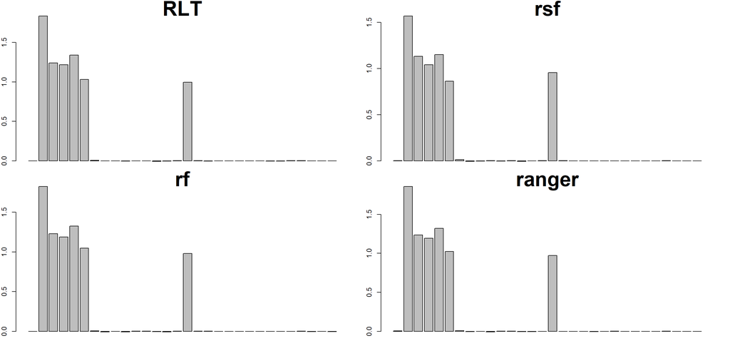

```r
  par(mfrow=c(2,2))
  par(mar = c(1, 2, 2, 2))

  barplot(as.vector(RLTfit$VarImp), main = "RLT", cex.main = 3)
  barplot(as.vector(rsffit$importance), main = "rsf", cex.main = 3)
  barplot(rf.fit$importance[, 1], main = "rf", cex.main = 3)
  barplot(as.vector(rangerfit$variable.importance), main = "ranger", cex.main = 3)
```